# mypokergames套件說明

M092040003 陳姿霖

# **安裝套件**

### 從Github上安裝下來

```r
library(devtools)
install_github("somnustp6/mypokergames")
```

我的的電腦R版本似乎比較舊,所以無法從本機安裝套件

所以我的套件請大家從我的Github安裝下來

想看詳細的程式碼：https://github.com/somnustp6/mypokergames

安裝成功後將套件用library匯入R

```r
library(mypokergames)
```

# **報告主題**

這是我設計的套件是針對兩個撲克牌遊戲：**九九、21點**

這兩款遊戲我會先稍微介紹遊戲方法,再來帶程式示例

程式的部分,我會盡量以圖片的方式呈現,避免直接跑程式導致版面過亂

實際跑程式的部分再請各位同學幫我玩玩看囉

# **九九**

## *遊戲規則*

限定2~4位玩家遊玩

#### 遊玩順序

確認玩家個數後,每人發五張牌,由系統決定出牌順序

打出一張牌後,系統會在自動補給你一張牌

依牌上的點數相加,最高只能達到99點

使牌面超過99點的玩家,立刻淘汰

其餘玩家繼續遊戲,直到剩下一位玩家為止

#### 牌面定義

##### 普通牌

● A(方塊A、紅心A、梅花A) ：加1點

● 2 : 加2點

● 3 : 加3點

● 6 : 加6點

● 7 : 加7點

● 8 : 加8點

● 9 : 加9點

##### 特別牌

● 4 : 迴轉,點數總和不變,改變出牌順序

● 5 : 指定,可以指定任何一位玩家換其出牌

● 10 : 加 10點 或是 減10點

● J : pass,跳過的意思(點數總和不變，換下一位玩家)

● Q : 加20點 或是 減20點

● K : 99,不論目前數字多少,點數總和變成99

● 黑桃A：歸0,可以將現有點數總和變成0

## *函數介紹*

```r
ninenine(n_people = 4,n_computer = 0,block = 10)
```

#### 係數

● **n_people:*{1,2,3,4}, default=4***

$\quad$遊玩遊戲的人數

● **n_computer:*{1,2,3,4}, default=0***

● **block:*int, default=10***

$\quad$阻擋偷看的行數  
$\quad$因為所有人的牌都會再同一張螢幕出現,因此在換人時會出現遮罩  
$\quad$可輸入任何正整數,所有玩家不會看到別人的牌為主

## *玩法示例*

這裡我以沒加入電腦的四人遊戲來做示範

##### 輸入函數ninenine()

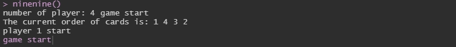

輸入函數後會顯示大家出牌的順序

確人完順序後即可由最先出牌的 player1 按下 enter 開始遊戲

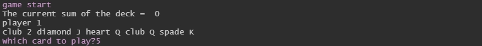

player1 就會看到“現在桌面上的點數總和”以及“自己有哪些牌”

player1 可以輸入自己想出的是第幾張牌,接著再按下 enter

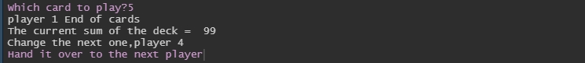

player1 輸入 5 後代表他出了 黑桃K 這張牌

player1 系統則顯示現在桌上的點數,以及下一位玩家是 player4

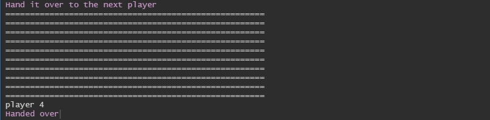

player1 按下 enter 後會出現遮罩,這時就可以將出牌權交給 player4

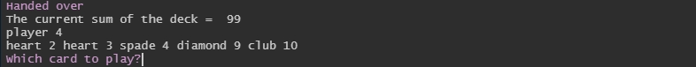

player4 接棒後按下 enter,就會看到“點數總和”以及“自己有哪些牌”

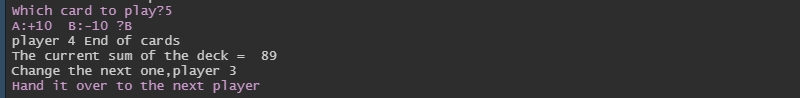

接著 player4 選擇出 梅花10 並選擇使牌面點數扣10

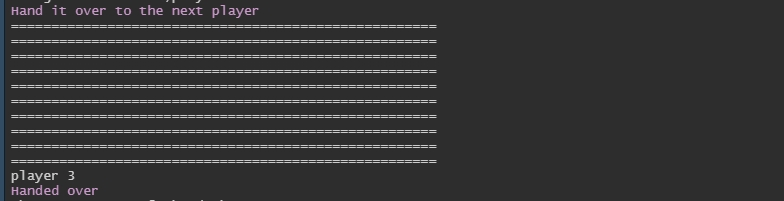

按下 enter 使牌權交給 player3

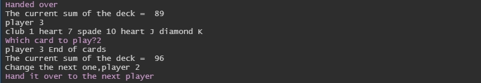

player3 選擇出普通牌 紅心7 並選擇使牌面點數加7

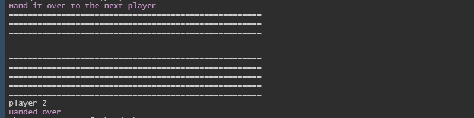

在交棒給 player2

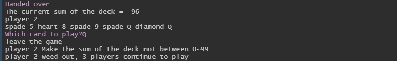

此時若 player2 想離開遊戲 他可以輸入 Q

系統就會判定 player2 是違反遊戲規則的人

player2 淘汰後其餘3位玩家繼續遊戲

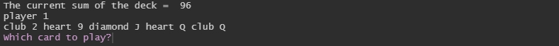

牌權按一開始的排序,輪到 player1 手上

可以發現在他第一輪出掉 黑桃K 後,系統補了 紅心9 給他

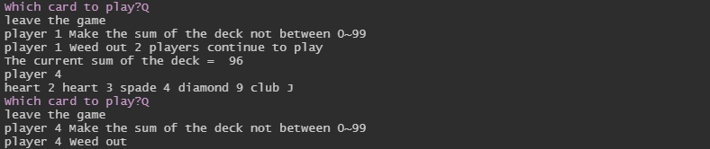

接者我假設, player1 與 player4 都接連離開遊戲

遊戲最後就會只剩下 player3 一人

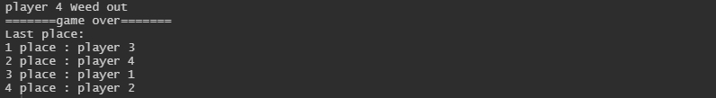

再按照淘汰順序,就決定出了這次遊玩九九的名次

這次示例並未放進電腦玩家,有興趣的同學可以試玩看看有電腦一起玩的版本喔

有電腦玩家的話,電腦在玩家的編號會加上c喔, 像: playerc1

##### 隨機性的應用

● **遊戲開始前**

$\quad$在發牌時牌堆都是隨機排序的  
$\quad$出牌的順序也是在確定人數後隨機安排的

● **遊戲進行中**

$\quad$出牌後補進的牌,是以遊戲前那隨機排序的牌堆來決定  
$\quad$當打出的牌到一定數量後,會重新洗牌補到原本的牌堆之下,以利遊戲長久進行

● **電腦玩家的設置**

$\quad$電腦每次出牌都是隨機選號碼來出的  
$\quad$當然也有設置過,除非沒功能牌可出,電腦不會自己選擇使牌面點數超過99的牌

# **21點**

限定2~4位玩家遊玩

## *遊戲規則*

網路上對於21點有很多種玩法,我稍微做過改編讓他更容易在程式上執行

遊戲當中有2~4位玩家與一位莊家,目的使自己的牌面總和接近但不超過21點

#### 遊玩順序

確認玩家個數後,系統會為每人發2張牌,一張明牌與一張暗牌

在遊戲開始前會給每位玩家確認暗牌為何,玩家根據手牌決定下注金額

遊戲開始後,各位玩家輪流選擇是否再拿牌

當所有玩家都不再牌,會掀開暗牌並結算各玩家獲得之點數

最後依照各玩家之點數決定輸贏並結算籌碼

#### 牌面定義

● A : 加1點 或 加11點

● 2 : 加2點

● 3 : 加3點

● 4 : 加4點

● 5 : 加5點

● 6 : 加6點

● 7 : 加7點

● 8 : 加8點

● 9 : 加9點

● 10 : 加10點

● J : 加10點

● Q : 加10點

● K : 加10點

● **莊家(Bank)**

$\quad$由電腦擔任,始終將A視為加1點,總點數達17就不再拿牌

● **爆牌(Bust)**

$\quad$代表該玩家的手牌超過21點

● **BlackJack**

$\quad$代表該玩家只有拿起手的兩張牌,就達到了21點

#### 勝負條件

● **有玩家達到BlackJack**

$\quad$支付兩倍賭金給該玩家

● **若莊家爆牌**

$\quad$支付一倍賭金給該未爆牌玩家  
$\quad$沒收爆牌玩家的賭金

● **若莊家未爆牌**

$\quad$支付一倍賭金給未爆牌且點數比莊家大的玩家  
$\quad$沒收爆牌玩家與點數比莊家小的人的賭金  
$\quad$若點數與莊家相同則平手,不沒收賭金

## *函數介紹*

```r
twentyone(n_people = 2,counter = 100,block = 10)
```

#### 係數

● **n_people:*{2,3,4}, default=2***

$\quad$遊玩遊戲的人數

● **counter:*int, default=100***

$\quad$起初每人的籌碼數量

● **block:*int, default=10***

$\quad$阻擋偷看的行數  
$\quad$在開始遊戲前,查看暗牌的階段,在換人時會出現遮罩  
$\quad$可輸入任何正整數,所有玩家不會看到別人的牌為主

## *玩法示例*

這裡我以兩人遊戲來做示範

##### 輸入函數twentyone()

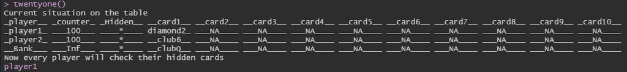

確認遊玩人數後,系統會展示牌桌目前的狀況

由於接下來會依序給玩家拿牌,所以還未拿牌的區域設為 NA

接著 player1 要到電腦前查看自己的暗牌

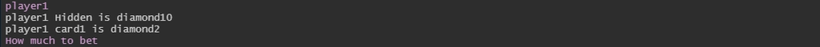

player1 確認完暗牌後下注

player1 確認自己牌面總和為12並下注50

按下 enter 準備給下一位玩家看暗牌

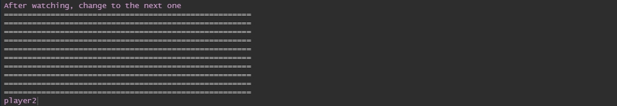

此時出現遮罩,換 player2 到螢幕前

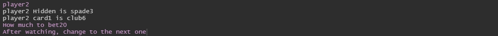

player2 確認牌面總和為9且下注

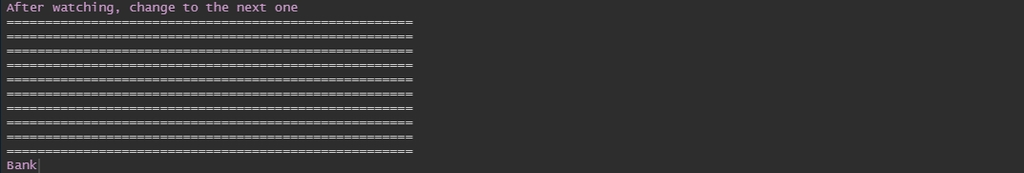

接著輪到莊家,由於莊家由電腦控制所以直接按下 enter 即可

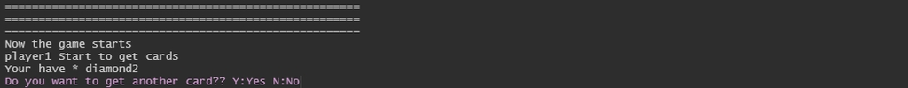

player1 開始決定是否拿牌

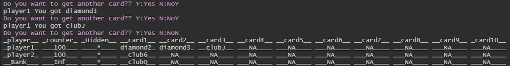

player1 已知自己一開始的牌面點數總合為12

想賭接下來拿到的牌不至於使自己爆牌

結果拿到第三張牌導致點數總合為25,已經爆牌所以不再拿牌

每位玩家拿完牌會再給所有玩家確認牌面狀況

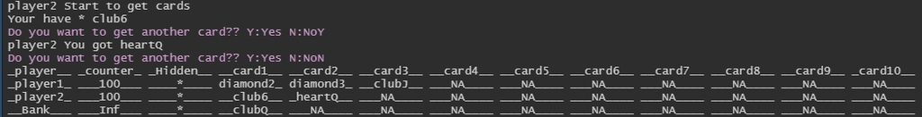

接著換 player2 開始拿牌

player2 發現自己牌面點數到達19了,擔心會爆牌所以不再拿牌

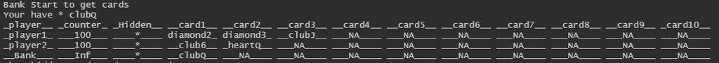

輪到 莊家,由電腦控制,所以會直接顯示 莊家 是否拿牌

莊家 在牌面小於17時,才會繼續拿牌

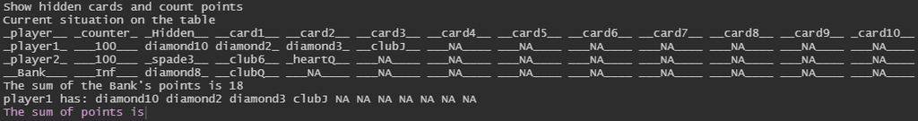

莊家 結束拿牌後,系統會將暗牌全部翻開,給所有玩家算點數

會先顯示 莊家 獲得的點數為18,接著由 player1 手動輸入自己獲得的點數

因為 A 這個牌面可能為 1 或 11,所以這裡設計給玩家自行輸入

避免玩家為了獲勝而輸入錯誤的點數,其餘玩家也可以一同查看輸入的值

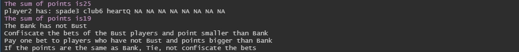

都輸入完點數後,系統換顯示賭金的計算方式

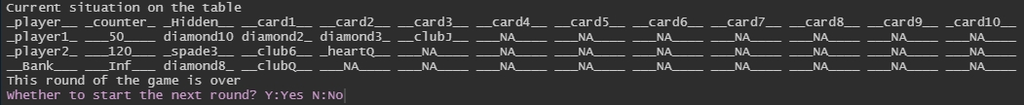

player1,下注50,輸了遊戲,因此籌碼變為50

player2,下注20,贏了遊戲,因此籌碼變為120

此局結束

接著可以決定是否帶著這些籌碼進行下一局

若有玩家破產,則是直接結束遊戲

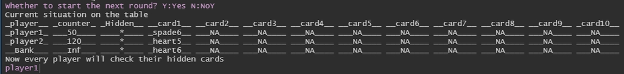

下一局若開始,籌碼會從上一局沿用下來

牌面重發,繼續開始遊戲

這次示例未提到有 BlackJack 與 莊家爆牌 的情況

大家也可以多嘗試看看,或許可以抓到贏錢的訣竅喔

##### 隨機性的應用

● **遊戲開始前**

$\quad$在發牌時牌堆都是隨機排序的  
$\quad$每一輪的遊戲開始前,都會洗過牌才發

● **遊戲進行中**

$\quad$中間拿到的牌,是以遊戲前那隨機排序的牌堆來決定